# Workflows for predicting staple food systems with association rule mining

## Staple crop diversity in proximity to buildings

However, we think that perhaps a better generalization, also for the purposes mapping and monitoring staple food crops, is by referencing where people live in close proximity to the food crops that they produce (e.g. as indexed by their proximity to buildings). In Rwanda most smallholder fields are located close to buildings. In Tanzania croplands are more dispersed over larger areas relative to where people actually reside, reflecting a large difference in the rural population densities between the two countries. We can actually explore this contention here because the occurrence of buildings with a 50 m radius of the PSUs was recorded in both the Tanzania and the Rwanda surveys.

```r
# Select crop occurrence variables and buildings and convert these to "transactions"
crops <- staple_ar[ , c(4:24)]
inter <- as(crops, "transactions")
```

```r
# Fit rules
buildr <- apriori(inter, parameter = list(target = "rule", support = mins, confidence = 0.5,
                                          minlen = 2))
```

```r
# Summarize rule set
summary(buildr)
```

```
## set of 62 rules
##
## rule length distribution (lhs + rhs):sizes
##  2  3
## 29 33
##
##    Min. 1st Qu.  Median    Mean 3rd Qu.    Max.
##   2.000   2.000   3.000   2.532   3.000   3.000
##
## summary of quality measures:
##     support          confidence        coverage            lift
##  Min.   :0.06143   Min.   :0.5066   Min.   :0.06562   Min.   :0.7124
##  1st Qu.:0.06797   1st Qu.:0.5760   1st Qu.:0.10170   1st Qu.:1.1995
##  Median :0.08578   Median :0.6462   Median :0.12596   Median :1.8235
##  Mean   :0.09510   Mean   :0.6766   Mean   :0.14622   Mean   :2.1844
##  3rd Qu.:0.10238   3rd Qu.:0.7826   3rd Qu.:0.17224   3rd Qu.:3.2448
##  Max.   :0.34536   Max.   :0.9390   Max.   :0.52626   Max.   :5.3905
##      count
##  Min.   :1013
##  1st Qu.:1121
##  Median :1414
##  Mean   :1568
##  3rd Qu.:1688
##  Max.   :5695
##
## mining info:
##   data ntransactions    support confidence
##  inter         16490 0.06064281        0.5
```

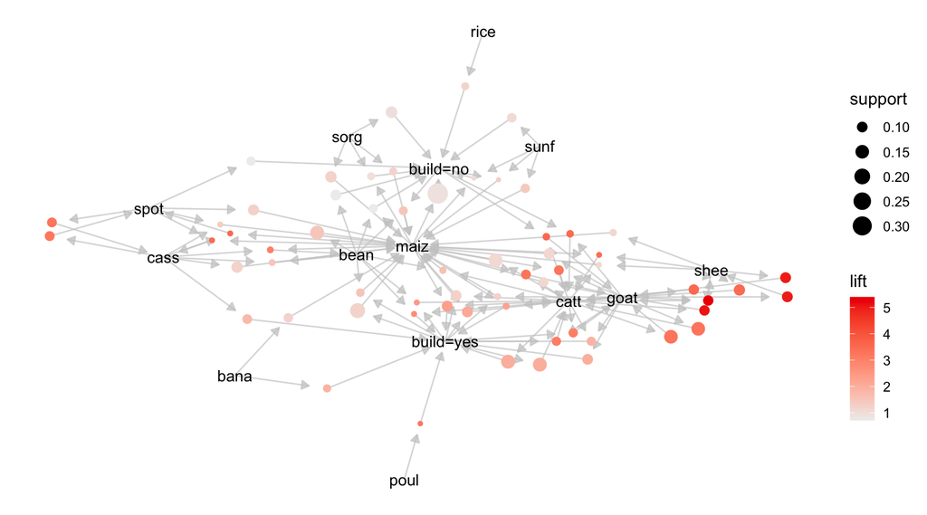

Association rule graph of the main staple food systems in Tanzania and Rwanda.

```r
plot(buildr, method = "graph")
```

```r
# Staple crop systems rule mining summary table
inspectDT(buildr)
```

|  | LHS | RHS | support | confidence | coverage | lift | count |
| --- | --- | --- | --- | --- | --- | --- | --- |
| [1] | {rice} | {build=no} | 0.0714978775015161 | 0.841541755888651 | 0.0849605821710127 | 1.1833396055772 | 1179 |
| [2] | {poul} | {build=yes} | 0.0616130988477865 | 0.939001848428835 | 0.0656155245603396 | 3.25092178891276 | 1016 |
| [3] | {sunf} | {build=no} | 0.086719223771983 | 0.757014293276866 | 0.114554275318375 | 1.06448074495911 | 1430 |
| [4] | {sunf} | {maiz} | 0.0842935112189206 | 0.735839068290101 | 0.114554275318375 | 1.39824685827423 | 1390 |
| [5] | {shee} | {goat} | 0.102243784111583 | 0.870418172431595 | 0.11746513038205 | 4.99589128555413 | 1686 |
| [6] | {goat} | {shee} | 0.102243784111583 | 0.586843021232161 | 0.174226804123711 | 4.99589128555413 | 1686 |
| [7] | {shee} | {catt} | 0.108429351121892 | 0.923076923076923 | 0.11746513038205 | 3.45865450159929 | 1788 |
| [8] | {shee} | {maiz} | 0.0676773802304427 | 0.576148683531234 | 0.11746513038205 | 1.09480200408274 | 1116 |
| [9] | {bana} | {build=yes} | 0.0733171619163129 | 0.545331529093369 | 0.134445118253487 | 1.88799431340535 | 1209 |
| [10] | {bana} | {maiz} | 0.0848392965433596 | 0.631032927379341 | 0.134445118253487 | 1.19909345154245 | 1399 |

[output cut: 52 more lines]

You can also look at association rules for specific crops e.g., maize in this case, with this next chunk. Note that you can filter these from the table directly above.

```r
maizr <- apriori(inter, parameter=list(support = mins, confidence = 0.5, minlen = 2),
                 appearance = list(default = "lhs", rhs = "maiz"),
                 control = list(verbose=T))
```

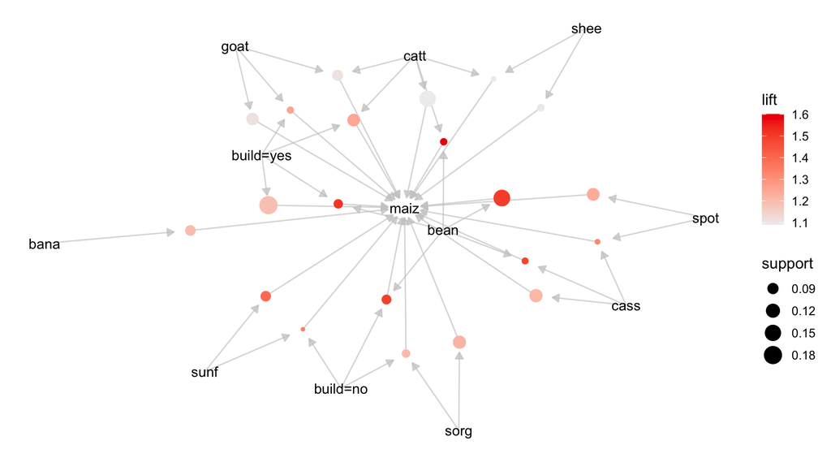

Association rule graph for maize-based systems in Tanzania and Rwanda.

## Labeling staple combinations (systems)

One thing that is missing from the `arules` package is a general function for labeling and predicting all combinations of PSUs and staple crops at any particular observed and/or new PSU based on the developed association rules. Fortunately, such a function has already been written by [J. de Jong (2016)](https://johanndejong.wordpress.com/2016/11/22/efficient-recommending-with-the-arules-package/). We have stolen it here because it is elegant and fast.

```r
recommend <- function(
  rules, # object with association rules
  newdata # item Matrix object
) {
    lhs_match <- is.superset(
    newdata,
    lhs(rules),
    sparse = TRUE
  )

  rec <- lhs_match %*% t(rhs(rules)@data)
  rownames(rec) <- rownames(newdata)
  colnames(rec) <- colnames(newdata)
  as(t(rec), "itemMatrix")
}
```

We can now use this next chunk to generate the staple cropping system labels based on the developed association rule-base, and a write-out to a dataframe. Of course, this could also be done for any new data.

```r
inter <- as(inter, "itemMatrix")
preds <- recommend(buildr, inter)
stapler <- DATAFRAME(preds)
staple_ar <- cbind(staple_ar, stapler)

# Write out tidy dataframe
write.csv(staple_ar, "./Food_system/Results/TZ_RW_staple_food_rules.csv", row.names = FALSE)

# Generates a glimpse of the resulting dataframe
glimpse(staple_ar)
```

```
## Rows: 16,490
## Columns: 27
## $ lon       <dbl> 36.55824, 36.55903, 36.55129, 36.54916, 36.55100, 36.55270, …
## $ lat       <dbl> -3.441613, -3.442471, -3.408656, -3.440615, -3.441583, -3.44…
## $ survey    <fct> TZ, TZ, TZ, TZ, TZ, TZ, TZ, TZ, TZ, TZ, TZ, TZ, TZ, TZ, TZ, …
## $ build     <fct> no, no, yes, yes, no, no, no, no, yes, yes, yes, no, no, no,…
## $ catt      <lgl> FALSE, FALSE, FALSE, FALSE, FALSE, FALSE, FALSE, FALSE, FALS…
## $ shee      <lgl> FALSE, FALSE, FALSE, FALSE, FALSE, FALSE, FALSE, FALSE, FALS…
## $ goat      <lgl> FALSE, FALSE, FALSE, FALSE, FALSE, FALSE, FALSE, FALSE, FALS…
## $ poul      <lgl> FALSE, FALSE, FALSE, FALSE, FALSE, FALSE, FALSE, FALSE, FALS…
## $ maiz      <lgl> TRUE, TRUE, TRUE, TRUE, TRUE, TRUE, TRUE, TRUE, FALSE, FALSE…
## $ whea      <lgl> FALSE, FALSE, FALSE, FALSE, FALSE, FALSE, FALSE, FALSE, FALS…
## $ sorg      <lgl> FALSE, FALSE, FALSE, FALSE, FALSE, FALSE, FALSE, FALSE, FALS…
## $ rice      <lgl> FALSE, FALSE, FALSE, FALSE, FALSE, FALSE, FALSE, FALSE, FALS…
## $ bean      <lgl> TRUE, TRUE, TRUE, TRUE, TRUE, TRUE, TRUE, TRUE, FALSE, FALSE…
## $ cpea      <lgl> FALSE, FALSE, FALSE, FALSE, FALSE, FALSE, FALSE, FALSE, FALS…
## $ pige      <lgl> FALSE, FALSE, TRUE, FALSE, FALSE, FALSE, FALSE, FALSE, FALSE…
## $ soyb      <lgl> FALSE, FALSE, FALSE, FALSE, FALSE, FALSE, FALSE, FALSE, FALS…
## $ gnut      <lgl> FALSE, FALSE, FALSE, FALSE, FALSE, FALSE, FALSE, FALSE, FALS…
## $ pota      <lgl> FALSE, FALSE, FALSE, FALSE, FALSE, FALSE, FALSE, FALSE, FALS…
## $ spot      <lgl> FALSE, FALSE, FALSE, FALSE, FALSE, FALSE, FALSE, FALSE, FALS…
## $ cass      <lgl> FALSE, FALSE, FALSE, FALSE, FALSE, FALSE, FALSE, FALSE, FALS…
## $ yam       <lgl> FALSE, FALSE, FALSE, FALSE, FALSE, FALSE, FALSE, FALSE, FALS…
## $ bana      <lgl> FALSE, FALSE, FALSE, FALSE, FALSE, FALSE, FALSE, FALSE, FALS…
## $ cane      <lgl> FALSE, FALSE, FALSE, FALSE, FALSE, FALSE, FALSE, FALSE, FALS…
## $ sunf      <lgl> FALSE, FALSE, FALSE, FALSE, FALSE, FALSE, FALSE, FALSE, FALS…
## $ sdiv      <dbl> 2, 2, 3, 2, 2, 2, 2, 2, 0, 3, 0, 1, 2, 0, 2, 2, 0, 2, 2, 0, …
## $ items     <fct> "{build=no,maiz}", "{build=no,maiz}", "{build=no,catt,maiz}"…
## $ itemsetID <chr> "1", "2", "3", "4", "5", "6", "7", "8", "9", "10", "11", "12…
```

## Class association rules

The approach presented in the next chunks can also be used to validate the mined association rules vis-á-vis other machine learning algorithms and/or subsequently used in various model prediction ensembles. We use it here to illustrate starter code for generating a supervised classification of intercropped (i.e., `sdiv > 1`) systems with the “Classification Based on Association Rules” (CBA) algorithm with the [`arulesCBA`](https://www.webpages.uidaho.edu/~stevel/517/arulesCBA.pdf) package.

```r
# Variable selection
staple_ar$inter <- as.factor(ifelse(staple_ar$sdiv > 1, "yes", "no"))
crops <- as.data.frame (staple_ar[ ,c(3,26,28)])

# Classification
class <- CBA(inter ~ ., crops)
preds <- predict(class, crops)
conf <- cbind(crops, preds)
confusionMatrix(conf$preds, reference = conf$inter, positive = "yes")
```

```
## Confusion Matrix and Statistics
##
##           Reference
## Prediction   no  yes
##        no  4934  385
##        yes 2078 9093
##
##                Accuracy : 0.8506
##                  95% CI : (0.8451, 0.856)
##     No Information Rate : 0.5748
##     P-Value [Acc > NIR] : < 2.2e-16
##
##                   Kappa : 0.6845
##
##  Mcnemar's Test P-Value : < 2.2e-16
##
##             Sensitivity : 0.9594
##             Specificity : 0.7037
##          Pos Pred Value : 0.8140
##          Neg Pred Value : 0.9276
##              Prevalence : 0.5748
##          Detection Rate : 0.5514
##    Detection Prevalence : 0.6774
##       Balanced Accuracy : 0.8315
##
##        'Positive' Class : yes
##
```

This does alright. The classifier is quite sensitive but not particularly specific. It does however generalize the intercropping observations in regard to filtering the two surveys and the potentially confounding proximity to buildings variable quite well, as is shown in the table below.

```r
# Classification rules
inspectDT(rules(class))
```

|  | LHS | RHS | support | confidence | coverage | lift | count | size | coveredTransactions | totalErrors |
| --- | --- | --- | --- | --- | --- | --- | --- | --- | --- | --- |
| [3] | {items={}} | {inter=no} | 0.163129169193451 | 0.998886000742666 | 0.16331109763493 | 2.34906305650978 | 2690 | 2 | 2693 | 4325 |
| [4] | {survey=RW} | {inter=yes} | 0.149848392965434 | 0.905791788856305 | 0.16543359611886 | 1.57591333596122 | 2471 | 2 | 2703 | 4325 |
| [6] | {survey=TZ,items={build=no}} | {inter=no} | 0.136082474226804 | 0.854531607006854 | 0.159248029108551 | 2.00958730740773 | 2244 | 3 | 2626 | 2463 |
| [inter=yes] | {} | {inter=yes} | 0.57477258944815 | 0.57477258944815 |  | 1 | 16490 | 1 | 8468 | 2463 |

# Summary: Our top-10 staple food crop association rules

This next chunk flags the main (identified) staple food crop association rules for Tanzania and Rwanda. These should guide and prioritize any subsequent surveys or experimental investigations of staple food systems (or versions thereof).

```r
rules <- as.data.frame(staple_ar$items)
trans <- as(rules, "transactions")
```

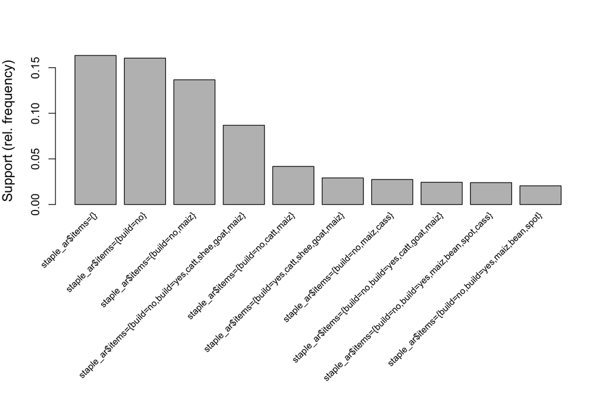

Top-10 staple crop association rules in Tanzania and Rwanda.

```r
itemFrequencyPlot(trans, topN = 10, ylab = "Support (rel. frequency)", cex.lab = 1.2, cex.names = 0.8)
```

# Takeaways

The main takeaways of this notebook are the following:

- The staple food crop models, which are considered in this notebook are already fairly complex, but they will require more learning to unpack completely. We have essentially only scratched the surface here. Nonetheless, the processes for proceeding are well grounded in a relatively simple algorithm, which provides fast, sensible results, and workable outputs for additional exploratory and predictive analyses.
- At first glance Rwanda’s staple food production systems appear to be more diverse than those typically found in Tanzania. However, this observation appears to be largely related to population density, as indicated by the proximity of buildings in croplands. Staple food cropping systems in proximity to buildings tend to be more complex and diverse in both Tanzania and Rwanda. This relationship appears to generalize the subsequent intercropping association rules quite well.
- The associated ground observations are easy to conduct over large areas, and only require access to a motorcycle and a smart phone … preferably using guided crowds of these in any given geography and during any given cropping season to be efficient.
- Association rules can be readily incorporated into any subsequent spatial machine learning and or geostatistical prediction procedures. We shall explore those possibilities in more depth with additional notebooks.
- There are also other analysis options, such as graphical interaction models ([Højsgaard, Edwards and Lauritzen, 2012](https://link.springer.com/book/10.1007/978-1-4614-2299-0)) as well as various clustering approaches (e.g., [Schubert and Rousseeuw, 2019](https://link.springer.com/chapter/10.1007%2F978-3-030-32047-8_16)), which we could use for the modeling the data that were presented here. We have not included these in this notebook to keep things relatively concise but might explore those options in additional notebooks at a later stage.

Any questions, comments or corrections related to this notebook are most welcome via AFSIS.

# Side note: Links to staple food recipes

Of course there are some delicious recipes out there for using the staple crops indicated this notebook for meals (some of these are also quite nutritious). Interestingly, cooking advisories such as [Supercook](https://www.supercook.com/#/recipes) and [Allrecipes](https://www.allrecipes.com/search/results/?search=) are also using new recommendation algorithms to help provide meal options based on what ingredients you have available, or what you may want to have available in your fridge and dry-goods store. If you are a smallholder in East Africa, those ingredients will largely depend on what you are growing on your land and whatever your breakfast, lunch or dinner preferences are. It might be interesting and informative to do a webscrape of recipe sites to see to what degree the staple foods explored here (co)occur in African and global food recipes. We shall leave that for another day.